# Risk Factor Analysis

## Outcome Variable

**Outcome Variable:** wast_rec90d

## Predictor Variables

**Intervention Variable:** exclfeed36

**Adjustment Set:**

- arm
- sex
- brthmon
- W_mage
- meducyrs
- feducyrs
- hhwealth_quart
- hfoodsec
- W_mhtcm
- W_mwtkg
- W_mbmi
- vagbrth
- W_gagebrth
- W_birthwt
- W_birthlen
- W_nrooms
- month
- W_parity
- impfloor
- impsan
- safeh20
- delta_W_mage
- delta_meducyrs
- delta_feducyrs
- delta_hhwealth_quart
- delta_hfoodsec
- delta_W_mhtcm
- delta_W_mwtkg
- delta_W_mbmi
- delta_vagbrth
- delta_W_gagebrth
- delta_W_birthwt
- delta_W_birthlen
- delta_W_nrooms
- delta_month
- delta_W_parity
- delta_impfloor
- delta_impsan
- delta_safeh20

## Stratifying Variables

The analysis was stratified on these variable(s):

- agecat
- studyid
- country

## Data Summary

| agecat | studyid | country | exclfeed36 | wast_rec90d | n_cell | n |
| --- | --- | --- | --- | --- | --- | --- |
| 0-24 months | CMC-V-BCS-2002 | INDIA | 1 | 0 | 2 | 5 |
| 0-24 months | CMC-V-BCS-2002 | INDIA | 1 | 1 | 3 | 5 |
| 0-24 months | CMC-V-BCS-2002 | INDIA | 0 | 0 | 0 | 5 |
| 0-24 months | CMC-V-BCS-2002 | INDIA | 0 | 1 | 0 | 5 |
| 0-24 months | EE | PAKISTAN | 1 | 0 | 1 | 4 |
| 0-24 months | EE | PAKISTAN | 1 | 1 | 0 | 4 |
| 0-24 months | EE | PAKISTAN | 0 | 0 | 0 | 4 |
| 0-24 months | EE | PAKISTAN | 0 | 1 | 3 | 4 |
| 0-24 months | GMS-Nepal | NEPAL | 1 | 0 | 190 | 559 |
| 0-24 months | GMS-Nepal | NEPAL | 1 | 1 | 257 | 559 |
| 0-24 months | GMS-Nepal | NEPAL | 0 | 0 | 52 | 559 |
| 0-24 months | GMS-Nepal | NEPAL | 0 | 1 | 60 | 559 |
| 0-24 months | IRC | INDIA | 1 | 0 | 0 | 5 |
| 0-24 months | IRC | INDIA | 1 | 1 | 0 | 5 |
| 0-24 months | IRC | INDIA | 0 | 0 | 3 | 5 |
| 0-24 months | IRC | INDIA | 0 | 1 | 2 | 5 |
| 0-24 months | JiVitA-3 | BANGLADESH | 1 | 0 | 1673 | 3743 |
| 0-24 months | JiVitA-3 | BANGLADESH | 1 | 1 | 1225 | 3743 |
| 0-24 months | JiVitA-3 | BANGLADESH | 0 | 0 | 498 | 3743 |
| 0-24 months | JiVitA-3 | BANGLADESH | 0 | 1 | 347 | 3743 |
| 0-24 months | JiVitA-4 | BANGLADESH | 1 | 0 | 946 | 1787 |
| 0-24 months | JiVitA-4 | BANGLADESH | 1 | 1 | 360 | 1787 |
| 0-24 months | JiVitA-4 | BANGLADESH | 0 | 0 | 347 | 1787 |
| 0-24 months | JiVitA-4 | BANGLADESH | 0 | 1 | 134 | 1787 |
| 0-24 months | Keneba | GAMBIA | 1 | 0 | 131 | 1460 |
| 0-24 months | Keneba | GAMBIA | 1 | 1 | 255 | 1460 |
| 0-24 months | Keneba | GAMBIA | 0 | 0 | 392 | 1460 |
| 0-24 months | Keneba | GAMBIA | 0 | 1 | 682 | 1460 |
| 0-24 months | LCNI-5 | MALAWI | 1 | 0 | 5 | 34 |
| 0-24 months | LCNI-5 | MALAWI | 1 | 1 | 2 | 34 |

[output cut: 174 more lines]

The following strata were considered:

- agecat: 0-24 months, studyid: CMC-V-BCS-2002, country: INDIA
- agecat: 0-24 months, studyid: EE, country: PAKISTAN
- agecat: 0-24 months, studyid: GMS-Nepal, country: NEPAL
- agecat: 0-24 months, studyid: IRC, country: INDIA
- agecat: 0-24 months, studyid: JiVitA-3, country: BANGLADESH
- agecat: 0-24 months, studyid: JiVitA-4, country: BANGLADESH
- agecat: 0-24 months, studyid: Keneba, country: GAMBIA
- agecat: 0-24 months, studyid: LCNI-5, country: MALAWI
- agecat: 0-24 months, studyid: MAL-ED, country: BANGLADESH
- agecat: 0-24 months, studyid: MAL-ED, country: BRAZIL
- agecat: 0-24 months, studyid: MAL-ED, country: INDIA
- agecat: 0-24 months, studyid: MAL-ED, country: NEPAL
- agecat: 0-24 months, studyid: MAL-ED, country: PERU
- agecat: 0-24 months, studyid: MAL-ED, country: SOUTH AFRICA
- agecat: 0-24 months, studyid: MAL-ED, country: TANZANIA, UNITED REPUBLIC OF
- agecat: 0-24 months, studyid: PROVIDE, country: BANGLADESH
- agecat: 0-24 months, studyid: SAS-FoodSuppl, country: INDIA
- agecat: 0-6 months, studyid: CMC-V-BCS-2002, country: INDIA
- agecat: 0-6 months, studyid: EE, country: PAKISTAN
- agecat: 0-6 months, studyid: GMS-Nepal, country: NEPAL
- agecat: 0-6 months, studyid: IRC, country: INDIA
- agecat: 0-6 months, studyid: JiVitA-3, country: BANGLADESH
- agecat: 0-6 months, studyid: JiVitA-4, country: BANGLADESH
- agecat: 0-6 months, studyid: Keneba, country: GAMBIA
- agecat: 0-6 months, studyid: LCNI-5, country: MALAWI
- agecat: 0-6 months, studyid: MAL-ED, country: BANGLADESH
- agecat: 0-6 months, studyid: MAL-ED, country: BRAZIL
- agecat: 0-6 months, studyid: MAL-ED, country: INDIA
- agecat: 0-6 months, studyid: MAL-ED, country: NEPAL
- agecat: 0-6 months, studyid: MAL-ED, country: PERU
- agecat: 0-6 months, studyid: MAL-ED, country: SOUTH AFRICA
- agecat: 0-6 months, studyid: MAL-ED, country: TANZANIA, UNITED REPUBLIC OF
- agecat: 0-6 months, studyid: PROVIDE, country: BANGLADESH
- agecat: 0-6 months, studyid: SAS-FoodSuppl, country: INDIA
- agecat: 6-24 months, studyid: CMC-V-BCS-2002, country: INDIA
- agecat: 6-24 months, studyid: EE, country: PAKISTAN
- agecat: 6-24 months, studyid: GMS-Nepal, country: NEPAL
- agecat: 6-24 months, studyid: IRC, country: INDIA
- agecat: 6-24 months, studyid: JiVitA-3, country: BANGLADESH
- agecat: 6-24 months, studyid: JiVitA-4, country: BANGLADESH
- agecat: 6-24 months, studyid: Keneba, country: GAMBIA
- agecat: 6-24 months, studyid: LCNI-5, country: MALAWI
- agecat: 6-24 months, studyid: MAL-ED, country: BANGLADESH
- agecat: 6-24 months, studyid: MAL-ED, country: BRAZIL
- agecat: 6-24 months, studyid: MAL-ED, country: INDIA
- agecat: 6-24 months, studyid: MAL-ED, country: NEPAL
- agecat: 6-24 months, studyid: MAL-ED, country: PERU
- agecat: 6-24 months, studyid: MAL-ED, country: SOUTH AFRICA
- agecat: 6-24 months, studyid: MAL-ED, country: TANZANIA, UNITED REPUBLIC OF
- agecat: 6-24 months, studyid: PROVIDE, country: BANGLADESH
- agecat: 6-24 months, studyid: SAS-FoodSuppl, country: INDIA

### Dropped Strata

Some strata were dropped due to rare outcomes:

- agecat: 0-24 months, studyid: CMC-V-BCS-2002, country: INDIA
- agecat: 0-24 months, studyid: EE, country: PAKISTAN
- agecat: 0-24 months, studyid: IRC, country: INDIA
- agecat: 0-24 months, studyid: LCNI-5, country: MALAWI
- agecat: 0-24 months, studyid: MAL-ED, country: BANGLADESH
- agecat: 0-24 months, studyid: MAL-ED, country: BRAZIL
- agecat: 0-24 months, studyid: MAL-ED, country: INDIA
- agecat: 0-24 months, studyid: MAL-ED, country: NEPAL
- agecat: 0-24 months, studyid: MAL-ED, country: PERU
- agecat: 0-24 months, studyid: MAL-ED, country: SOUTH AFRICA
- agecat: 0-24 months, studyid: MAL-ED, country: TANZANIA, UNITED REPUBLIC OF
- agecat: 0-24 months, studyid: SAS-FoodSuppl, country: INDIA
- agecat: 0-6 months, studyid: CMC-V-BCS-2002, country: INDIA
- agecat: 0-6 months, studyid: EE, country: PAKISTAN
- agecat: 0-6 months, studyid: IRC, country: INDIA
- agecat: 0-6 months, studyid: LCNI-5, country: MALAWI
- agecat: 0-6 months, studyid: MAL-ED, country: BANGLADESH
- agecat: 0-6 months, studyid: MAL-ED, country: BRAZIL
- agecat: 0-6 months, studyid: MAL-ED, country: INDIA
- agecat: 0-6 months, studyid: MAL-ED, country: NEPAL
- agecat: 0-6 months, studyid: MAL-ED, country: PERU
- agecat: 0-6 months, studyid: MAL-ED, country: SOUTH AFRICA
- agecat: 0-6 months, studyid: MAL-ED, country: TANZANIA, UNITED REPUBLIC OF
- agecat: 0-6 months, studyid: PROVIDE, country: BANGLADESH
- agecat: 0-6 months, studyid: SAS-FoodSuppl, country: INDIA
- agecat: 6-24 months, studyid: CMC-V-BCS-2002, country: INDIA
- agecat: 6-24 months, studyid: EE, country: PAKISTAN
- agecat: 6-24 months, studyid: IRC, country: INDIA
- agecat: 6-24 months, studyid: JiVitA-3, country: BANGLADESH
- agecat: 6-24 months, studyid: LCNI-5, country: MALAWI
- agecat: 6-24 months, studyid: MAL-ED, country: BANGLADESH
- agecat: 6-24 months, studyid: MAL-ED, country: BRAZIL
- agecat: 6-24 months, studyid: MAL-ED, country: INDIA
- agecat: 6-24 months, studyid: MAL-ED, country: NEPAL
- agecat: 6-24 months, studyid: MAL-ED, country: PERU
- agecat: 6-24 months, studyid: MAL-ED, country: SOUTH AFRICA
- agecat: 6-24 months, studyid: MAL-ED, country: TANZANIA, UNITED REPUBLIC OF
- agecat: 6-24 months, studyid: SAS-FoodSuppl, country: INDIA

## Methods Detail

We’re interested in the causal parameters $E[Y_a]$ for all values of $a \in \mathcal{A}$. These parameters represent the mean outcome if, possibly contrary to fact, we intervened to set all units to have $A=a$. Under the randomization and positivity assumptions, these are identified by the statistical parameters $\psi_a=E_W[E_{Y|A,W}(Y|A=a,W)]$. In addition, we’re interested in the mean of $Y$, $E[Y]$ under no intervention (the observed mean). We will estimate these parameters by using SuperLearner to fit the relevant likelihood factors – $E_{Y|A,W}(Y|A=a,W)$ and $p(A=a|W)$, and then updating our likelihood fit using a joint TMLE.

For unadjusted analyses ($W=\{\}$), initial likelihoods were estimated using Lrnr_glm to estimate the simple $E(Y|A)$ and Lrnr_mean to estimate $p(A)$. For adjusted analyses, a small library containing Lrnr_glmnet, Lrnr_xgboost, and Lrnr_mean was used.

Having estimated these parameters, we will then use the delta method to estimate relative risks and attributable risks relative to a prespecified baseline level of $A$.

# Results Detail

## Results Plots

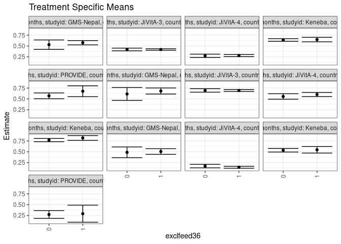

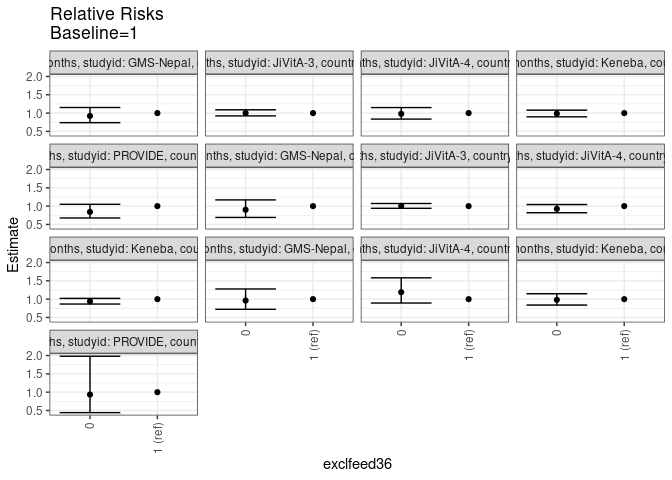

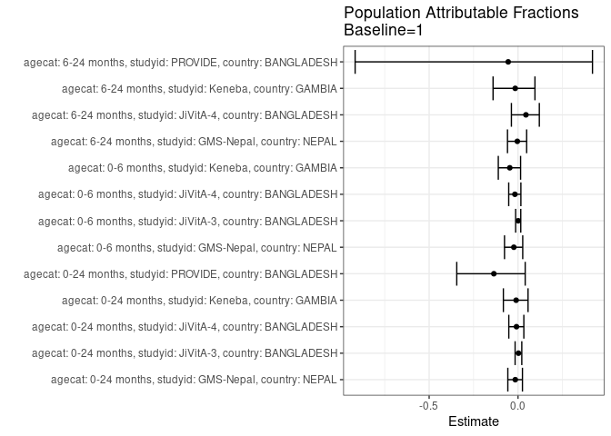

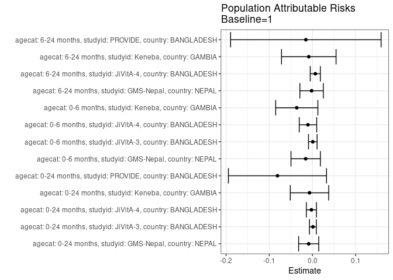

## Results Table

### Parameter: TSM

| agecat | studyid | country | intervention_level | baseline_level | estimate | ci_lower | ci_upper |
| --- | --- | --- | --- | --- | --- | --- | --- |
| 0-24 months | GMS-Nepal | NEPAL | 1 | NA | 0.5757676 | 0.5259269 | 0.6256083 |
| 0-24 months | GMS-Nepal | NEPAL | 0 | NA | 0.5311258 | 0.4220493 | 0.6402024 |
| 0-24 months | JiVitA-3 | BANGLADESH | 1 | NA | 0.4188778 | 0.4012402 | 0.4365154 |
| 0-24 months | JiVitA-3 | BANGLADESH | 0 | NA | 0.4198803 | 0.3885615 | 0.4511990 |
| 0-24 months | JiVitA-4 | BANGLADESH | 1 | NA | 0.2788183 | 0.2543201 | 0.3033164 |
| 0-24 months | JiVitA-4 | BANGLADESH | 0 | NA | 0.2733335 | 0.2347377 | 0.3119293 |
| 0-24 months | Keneba | GAMBIA | 1 | NA | 0.6485545 | 0.5963902 | 0.7007187 |
| 0-24 months | Keneba | GAMBIA | 0 | NA | 0.6385834 | 0.6082869 | 0.6688800 |
| 0-24 months | PROVIDE | BANGLADESH | 1 | NA | 0.6768561 | 0.5514801 | 0.8022320 |
| 0-24 months | PROVIDE | BANGLADESH | 0 | NA | 0.5700070 | 0.5027456 | 0.6372683 |
| 0-6 months | GMS-Nepal | NEPAL | 1 | NA | 0.6822855 | 0.6119391 | 0.7526318 |
| 0-6 months | GMS-Nepal | NEPAL | 0 | NA | 0.6136258 | 0.4647535 | 0.7624981 |
| 0-6 months | JiVitA-3 | BANGLADESH | 1 | NA | 0.6931932 | 0.6717532 | 0.7146333 |
| 0-6 months | JiVitA-3 | BANGLADESH | 0 | NA | 0.6954967 | 0.6552630 | 0.7357305 |
| 0-6 months | JiVitA-4 | BANGLADESH | 1 | NA | 0.6014268 | 0.5536640 | 0.6491896 |
| 0-6 months | JiVitA-4 | BANGLADESH | 0 | NA | 0.5560386 | 0.4926244 | 0.6194527 |
| 0-6 months | Keneba | GAMBIA | 1 | NA | 0.8192168 | 0.7641183 | 0.8743154 |
| 0-6 months | Keneba | GAMBIA | 0 | NA | 0.7701823 | 0.7325117 | 0.8078529 |
| 6-24 months | GMS-Nepal | NEPAL | 1 | NA | 0.5063032 | 0.4413792 | 0.5712272 |
| 6-24 months | GMS-Nepal | NEPAL | 0 | NA | 0.4869072 | 0.3624057 | 0.6114087 |
| 6-24 months | JiVitA-4 | BANGLADESH | 1 | NA | 0.1420683 | 0.1202222 | 0.1639143 |
| 6-24 months | JiVitA-4 | BANGLADESH | 0 | NA | 0.1689494 | 0.1283054 | 0.2095935 |
| 6-24 months | Keneba | GAMBIA | 1 | NA | 0.5454379 | 0.4703828 | 0.6204929 |
| 6-24 months | Keneba | GAMBIA | 0 | NA | 0.5350417 | 0.4936905 | 0.5763929 |
| 6-24 months | PROVIDE | BANGLADESH | 1 | NA | 0.2916667 | 0.0943448 | 0.4889886 |
| 6-24 months | PROVIDE | BANGLADESH | 0 | NA | 0.2727273 | 0.1836941 | 0.3617604 |

### Parameter: E(Y)

| agecat | studyid | country | intervention_level | baseline_level | estimate | ci_lower | ci_upper |
| --- | --- | --- | --- | --- | --- | --- | --- |
| 0-24 months | GMS-Nepal | NEPAL | NA | NA | 0.5670841 | 0.5219813 | 0.6121868 |
| 0-24 months | JiVitA-3 | BANGLADESH | NA | NA | 0.4199840 | 0.4041851 | 0.4357828 |
| 0-24 months | JiVitA-4 | BANGLADESH | NA | NA | 0.2764410 | 0.2550939 | 0.2977881 |
| 0-24 months | Keneba | GAMBIA | NA | NA | 0.6417808 | 0.6154966 | 0.6680651 |
| 0-24 months | PROVIDE | BANGLADESH | NA | NA | 0.5958904 | 0.5383795 | 0.6534013 |
| 0-6 months | GMS-Nepal | NEPAL | NA | NA | 0.6666667 | 0.6030996 | 0.7302337 |
| 0-6 months | JiVitA-3 | BANGLADESH | NA | NA | 0.6940397 | 0.6750581 | 0.7130214 |
| 0-6 months | JiVitA-4 | BANGLADESH | NA | NA | 0.5910853 | 0.5486247 | 0.6335459 |
| 0-6 months | Keneba | GAMBIA | NA | NA | 0.7829582 | 0.7512519 | 0.8146645 |
| 6-24 months | GMS-Nepal | NEPAL | NA | NA | 0.5043732 | 0.4466684 | 0.5620780 |
| 6-24 months | JiVitA-4 | BANGLADESH | NA | NA | 0.1487018 | 0.1295178 | 0.1678858 |
| 6-24 months | Keneba | GAMBIA | NA | NA | 0.5369928 | 0.5007974 | 0.5731883 |
| 6-24 months | PROVIDE | BANGLADESH | NA | NA | 0.2764228 | 0.1950773 | 0.3577682 |

### Parameter: RR

| agecat | studyid | country | intervention_level | baseline_level | estimate | ci_lower | ci_upper |
| --- | --- | --- | --- | --- | --- | --- | --- |
| 0-24 months | GMS-Nepal | NEPAL | 1 | 1 | 1.0000000 | 1.0000000 | 1.000000 |
| 0-24 months | GMS-Nepal | NEPAL | 0 | 1 | 0.9224657 | 0.7382875 | 1.152590 |
| 0-24 months | JiVitA-3 | BANGLADESH | 1 | 1 | 1.0000000 | 1.0000000 | 1.000000 |
| 0-24 months | JiVitA-3 | BANGLADESH | 0 | 1 | 1.0023933 | 0.9223957 | 1.089329 |
| 0-24 months | JiVitA-4 | BANGLADESH | 1 | 1 | 1.0000000 | 1.0000000 | 1.000000 |
| 0-24 months | JiVitA-4 | BANGLADESH | 0 | 1 | 0.9803287 | 0.8355695 | 1.150167 |
| 0-24 months | Keneba | GAMBIA | 1 | 1 | 1.0000000 | 1.0000000 | 1.000000 |
| 0-24 months | Keneba | GAMBIA | 0 | 1 | 0.9846258 | 0.8973914 | 1.080340 |
| 0-24 months | PROVIDE | BANGLADESH | 1 | 1 | 1.0000000 | 1.0000000 | 1.000000 |
| 0-24 months | PROVIDE | BANGLADESH | 0 | 1 | 0.8421391 | 0.6755469 | 1.049813 |
| 0-6 months | GMS-Nepal | NEPAL | 1 | 1 | 1.0000000 | 1.0000000 | 1.000000 |
| 0-6 months | GMS-Nepal | NEPAL | 0 | 1 | 0.8993681 | 0.6911599 | 1.170298 |
| 0-6 months | JiVitA-3 | BANGLADESH | 1 | 1 | 1.0000000 | 1.0000000 | 1.000000 |
| 0-6 months | JiVitA-3 | BANGLADESH | 0 | 1 | 1.0033230 | 0.9398373 | 1.071097 |
| 0-6 months | JiVitA-4 | BANGLADESH | 1 | 1 | 1.0000000 | 1.0000000 | 1.000000 |
| 0-6 months | JiVitA-4 | BANGLADESH | 0 | 1 | 0.9245325 | 0.8191638 | 1.043455 |
| 0-6 months | Keneba | GAMBIA | 1 | 1 | 1.0000000 | 1.0000000 | 1.000000 |
| 0-6 months | Keneba | GAMBIA | 0 | 1 | 0.9401446 | 0.8660970 | 1.020523 |
| 6-24 months | GMS-Nepal | NEPAL | 1 | 1 | 1.0000000 | 1.0000000 | 1.000000 |
| 6-24 months | GMS-Nepal | NEPAL | 0 | 1 | 0.9616909 | 0.7232080 | 1.278815 |
| 6-24 months | JiVitA-4 | BANGLADESH | 1 | 1 | 1.0000000 | 1.0000000 | 1.000000 |
| 6-24 months | JiVitA-4 | BANGLADESH | 0 | 1 | 1.1892131 | 0.8938413 | 1.582191 |
| 6-24 months | Keneba | GAMBIA | 1 | 1 | 1.0000000 | 1.0000000 | 1.000000 |
| 6-24 months | Keneba | GAMBIA | 0 | 1 | 0.9809398 | 0.8382733 | 1.147887 |
| 6-24 months | PROVIDE | BANGLADESH | 1 | 1 | 1.0000000 | 1.0000000 | 1.000000 |
| 6-24 months | PROVIDE | BANGLADESH | 0 | 1 | 0.9350649 | 0.4411401 | 1.982015 |

### Parameter: PAR

| agecat | studyid | country | intervention_level | baseline_level | estimate | ci_lower | ci_upper |
| --- | --- | --- | --- | --- | --- | --- | --- |
| 0-24 months | GMS-Nepal | NEPAL | 1 | NA | -0.0086835 | -0.0319647 | 0.0145977 |
| 0-24 months | JiVitA-3 | BANGLADESH | 1 | NA | 0.0011062 | -0.0067916 | 0.0090040 |
| 0-24 months | JiVitA-4 | BANGLADESH | 1 | NA | -0.0023773 | -0.0140670 | 0.0093124 |
| 0-24 months | Keneba | GAMBIA | 1 | NA | -0.0067736 | -0.0512949 | 0.0377477 |
| 0-24 months | PROVIDE | BANGLADESH | 1 | NA | -0.0809657 | -0.1945940 | 0.0326627 |
| 0-6 months | GMS-Nepal | NEPAL | 1 | NA | -0.0156188 | -0.0496664 | 0.0184288 |
| 0-6 months | JiVitA-3 | BANGLADESH | 1 | NA | 0.0008465 | -0.0091297 | 0.0108227 |
| 0-6 months | JiVitA-4 | BANGLADESH | 1 | NA | -0.0103415 | -0.0305789 | 0.0098959 |
| 0-6 months | Keneba | GAMBIA | 1 | NA | -0.0362586 | -0.0851377 | 0.0126204 |
| 6-24 months | GMS-Nepal | NEPAL | 1 | NA | -0.0019300 | -0.0291023 | 0.0252423 |
| 6-24 months | JiVitA-4 | BANGLADESH | 1 | NA | 0.0066335 | -0.0050568 | 0.0183239 |
| 6-24 months | Keneba | GAMBIA | 1 | NA | -0.0084450 | -0.0716255 | 0.0547355 |
| 6-24 months | PROVIDE | BANGLADESH | 1 | NA | -0.0152439 | -0.1895523 | 0.1590645 |

### Parameter: PAF

| agecat | studyid | country | intervention_level | baseline_level | estimate | ci_lower | ci_upper |
| --- | --- | --- | --- | --- | --- | --- | --- |
| 0-24 months | GMS-Nepal | NEPAL | 1 | NA | -0.0153126 | -0.0572825 | 0.0249913 |
| 0-24 months | JiVitA-3 | BANGLADESH | 1 | NA | 0.0026339 | -0.0163495 | 0.0212627 |
| 0-24 months | JiVitA-4 | BANGLADESH | 1 | NA | -0.0085996 | -0.0517795 | 0.0328075 |
| 0-24 months | Keneba | GAMBIA | 1 | NA | -0.0105545 | -0.0823544 | 0.0564825 |
| 0-24 months | PROVIDE | BANGLADESH | 1 | NA | -0.1358734 | -0.3446246 | 0.0404695 |
| 0-6 months | GMS-Nepal | NEPAL | 1 | NA | -0.0234282 | -0.0759827 | 0.0265594 |
| 0-6 months | JiVitA-3 | BANGLADESH | 1 | NA | 0.0012197 | -0.0132584 | 0.0154909 |
| 0-6 months | JiVitA-4 | BANGLADESH | 1 | NA | -0.0174958 | -0.0522879 | 0.0161460 |
| 0-6 months | Keneba | GAMBIA | 1 | NA | -0.0463098 | -0.1108982 | 0.0145234 |
| 6-24 months | GMS-Nepal | NEPAL | 1 | NA | -0.0038266 | -0.0591521 | 0.0486089 |
| 6-24 months | JiVitA-4 | BANGLADESH | 1 | NA | 0.0446097 | -0.0371778 | 0.1199477 |
| 6-24 months | Keneba | GAMBIA | 1 | NA | -0.0157265 | -0.1403869 | 0.0953068 |
| 6-24 months | PROVIDE | BANGLADESH | 1 | NA | -0.0551471 | -0.9164156 | 0.4190533 |